# Optimal Treatment Analysis

## Outcome Variable

**Outcome Variable:** whz

## Predictor Variables

**Intervention Variable:** feducyrs

**Adjustment Set:**

- arm
- W_mage
- meducyrs
- W_mhtcm
- W_gagebrth
- W_birthwt
- W_birthlen
- single
- delta_W_mage
- delta_meducyrs
- delta_W_mhtcm
- delta_W_gagebrth
- delta_W_birthwt
- delta_W_birthlen
- delta_single

## Stratifying Variables

The analysis was stratified on these variable(s):

- agecat
- studyid
- country

## Data Summary

| agecat | studyid | country | feducyrs | n_cell | n |
| --- | --- | --- | --- | --- | --- |
| Birth | ki0047075b-MAL-ED | BANGLADESH | High | 49 | 134 |
| Birth | ki0047075b-MAL-ED | BANGLADESH | Low | 35 | 134 |
| Birth | ki0047075b-MAL-ED | BANGLADESH | Medium | 50 | 134 |
| Birth | ki0047075b-MAL-ED | INDIA | High | 38 | 121 |
| Birth | ki0047075b-MAL-ED | INDIA | Low | 48 | 121 |
| Birth | ki0047075b-MAL-ED | INDIA | Medium | 35 | 121 |
| Birth | ki0047075b-MAL-ED | NEPAL | High | 27 | 64 |
| Birth | ki0047075b-MAL-ED | NEPAL | Low | 18 | 64 |
| Birth | ki0047075b-MAL-ED | NEPAL | Medium | 19 | 64 |
| Birth | ki0047075b-MAL-ED | PERU | High | 112 | 230 |
| Birth | ki0047075b-MAL-ED | PERU | Low | 63 | 230 |
| Birth | ki0047075b-MAL-ED | PERU | Medium | 55 | 230 |
| Birth | ki0047075b-MAL-ED | SOUTH AFRICA | High | 35 | 91 |
| Birth | ki0047075b-MAL-ED | SOUTH AFRICA | Low | 30 | 91 |
| Birth | ki0047075b-MAL-ED | SOUTH AFRICA | Medium | 26 | 91 |
| Birth | ki0047075b-MAL-ED | TANZANIA, UNITED REPUBLIC OF | High | 63 | 96 |
| Birth | ki0047075b-MAL-ED | TANZANIA, UNITED REPUBLIC OF | Low | 27 | 96 |
| Birth | ki0047075b-MAL-ED | TANZANIA, UNITED REPUBLIC OF | Medium | 6 | 96 |
| Birth | ki1000304b-SAS-CompFeed | INDIA | High | 33 | 166 |
| Birth | ki1000304b-SAS-CompFeed | INDIA | Low | 68 | 166 |
| Birth | ki1000304b-SAS-CompFeed | INDIA | Medium | 65 | 166 |
| Birth | ki1017093c-NIH-Crypto | BANGLADESH | High | 7 | 23 |
| Birth | ki1017093c-NIH-Crypto | BANGLADESH | Low | 11 | 23 |
| Birth | ki1017093c-NIH-Crypto | BANGLADESH | Medium | 5 | 23 |
| Birth | ki1119695-PROBIT | BELARUS | High | 2050 | 13359 |
| Birth | ki1119695-PROBIT | BELARUS | Low | 5294 | 13359 |
| Birth | ki1119695-PROBIT | BELARUS | Medium | 6015 | 13359 |
| Birth | ki1126311-ZVITAMBO | ZIMBABWE | High | 914 | 12572 |
| Birth | ki1126311-ZVITAMBO | ZIMBABWE | Low | 2090 | 12572 |
| Birth | ki1126311-ZVITAMBO | ZIMBABWE | Medium | 9568 | 12572 |

[output cut: 129 more lines]

The following strata were considered:

- agecat: 24 months, studyid: ki0047075b-MAL-ED, country: BANGLADESH
- agecat: 24 months, studyid: ki0047075b-MAL-ED, country: INDIA
- agecat: 24 months, studyid: ki0047075b-MAL-ED, country: NEPAL
- agecat: 24 months, studyid: ki0047075b-MAL-ED, country: PERU
- agecat: 24 months, studyid: ki0047075b-MAL-ED, country: SOUTH AFRICA
- agecat: 24 months, studyid: ki0047075b-MAL-ED, country: TANZANIA, UNITED REPUBLIC OF
- agecat: 24 months, studyid: ki1017093b-PROVIDE, country: BANGLADESH
- agecat: 24 months, studyid: ki1017093c-NIH-Crypto, country: BANGLADESH
- agecat: 24 months, studyid: ki1066203-TanzaniaChild2, country: TANZANIA, UNITED REPUBLIC OF
- agecat: 24 months, studyid: ki1113344-GMS-Nepal, country: NEPAL
- agecat: 24 months, studyid: ki1119695-PROBIT, country: BELARUS
- agecat: 24 months, studyid: ki1126311-ZVITAMBO, country: ZIMBABWE
- agecat: 24 months, studyid: ki1135781-COHORTS, country: GUATEMALA
- agecat: 24 months, studyid: ki1135781-COHORTS, country: INDIA
- agecat: 24 months, studyid: ki1135781-COHORTS, country: PHILIPPINES
- agecat: 24 months, studyid: ki1148112-LCNI-5, country: MALAWI
- agecat: 24 months, studyid: kiGH5241-JiVitA-3, country: BANGLADESH
- agecat: 24 months, studyid: kiGH5241-JiVitA-4, country: BANGLADESH
- agecat: 6 months, studyid: ki0047075b-MAL-ED, country: BANGLADESH
- agecat: 6 months, studyid: ki0047075b-MAL-ED, country: INDIA
- agecat: 6 months, studyid: ki0047075b-MAL-ED, country: NEPAL
- agecat: 6 months, studyid: ki0047075b-MAL-ED, country: PERU
- agecat: 6 months, studyid: ki0047075b-MAL-ED, country: SOUTH AFRICA
- agecat: 6 months, studyid: ki0047075b-MAL-ED, country: TANZANIA, UNITED REPUBLIC OF
- agecat: 6 months, studyid: ki1000304b-SAS-CompFeed, country: INDIA
- agecat: 6 months, studyid: ki1000304b-SAS-FoodSuppl, country: INDIA
- agecat: 6 months, studyid: ki1017093b-PROVIDE, country: BANGLADESH
- agecat: 6 months, studyid: ki1017093c-NIH-Crypto, country: BANGLADESH
- agecat: 6 months, studyid: ki1066203-TanzaniaChild2, country: TANZANIA, UNITED REPUBLIC OF
- agecat: 6 months, studyid: ki1113344-GMS-Nepal, country: NEPAL
- agecat: 6 months, studyid: ki1119695-PROBIT, country: BELARUS
- agecat: 6 months, studyid: ki1126311-ZVITAMBO, country: ZIMBABWE
- agecat: 6 months, studyid: ki1135781-COHORTS, country: GUATEMALA
- agecat: 6 months, studyid: ki1135781-COHORTS, country: INDIA
- agecat: 6 months, studyid: ki1135781-COHORTS, country: PHILIPPINES
- agecat: 6 months, studyid: ki1148112-LCNI-5, country: MALAWI
- agecat: 6 months, studyid: kiGH5241-JiVitA-3, country: BANGLADESH
- agecat: 6 months, studyid: kiGH5241-JiVitA-4, country: BANGLADESH
- agecat: Birth, studyid: ki0047075b-MAL-ED, country: BANGLADESH
- agecat: Birth, studyid: ki0047075b-MAL-ED, country: INDIA
- agecat: Birth, studyid: ki0047075b-MAL-ED, country: NEPAL
- agecat: Birth, studyid: ki0047075b-MAL-ED, country: PERU
- agecat: Birth, studyid: ki0047075b-MAL-ED, country: SOUTH AFRICA
- agecat: Birth, studyid: ki0047075b-MAL-ED, country: TANZANIA, UNITED REPUBLIC OF
- agecat: Birth, studyid: ki1000304b-SAS-CompFeed, country: INDIA
- agecat: Birth, studyid: ki1017093c-NIH-Crypto, country: BANGLADESH
- agecat: Birth, studyid: ki1119695-PROBIT, country: BELARUS
- agecat: Birth, studyid: ki1126311-ZVITAMBO, country: ZIMBABWE
- agecat: Birth, studyid: ki1135781-COHORTS, country: GUATEMALA
- agecat: Birth, studyid: ki1135781-COHORTS, country: INDIA
- agecat: Birth, studyid: ki1135781-COHORTS, country: PHILIPPINES
- agecat: Birth, studyid: kiGH5241-JiVitA-3, country: BANGLADESH
- agecat: Birth, studyid: kiGH5241-JiVitA-4, country: BANGLADESH

### Dropped Strata

Some strata were dropped due to rare outcomes:

- agecat: 24 months, studyid: ki1066203-TanzaniaChild2, country: TANZANIA, UNITED REPUBLIC OF

## Methods Detail

We’re interested in the causal parameters $E[Y_a]$ for all values of $a \in \mathcal{A}$. These parameters represent the mean outcome if, possibly contrary to fact, we intervened to set all units to have $A=a$. Under the randomization and positivity assumptions, these are identified by the statistical parameters $\psi_a=E_W[E_{Y|A,W}(Y|A=a,W)]$. In addition, we’re interested in the mean of $Y$, $E[Y]$ under no intervention (the observed mean). We will estimate these parameters by using SuperLearner to fit the relevant likelihood factors – $E_{Y|A,W}(Y|A=a,W)$ and $p(A=a|W)$, and then updating our likelihood fit using a joint TMLE.

For unadjusted analyses ($W=\{\}$), initial likelihoods were estimated using Lrnr_glm to estimate the simple $E(Y|A)$ and Lrnr_mean to estimate $p(A)$. For adjusted analyses, a small library containing Lrnr_glmnet, Lrnr_xgboost, and Lrnr_mean was used.

Having estimated these parameters, we will then use the delta method to estimate relative risks and attributable risks relative to a prespecified baseline level of $A$.

# Results Detail

## Results Plots

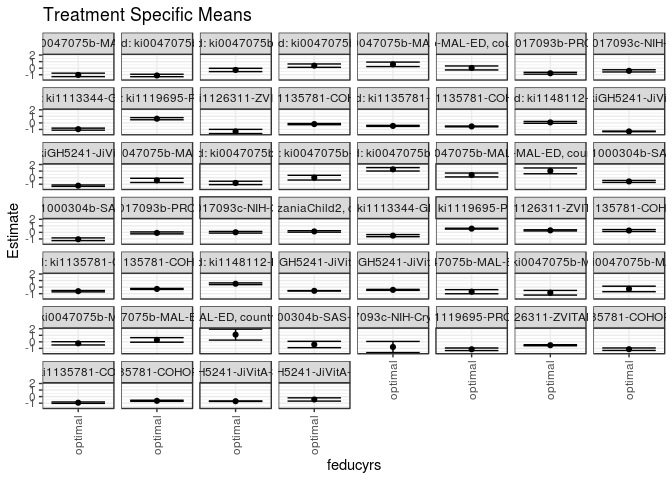

## Results Table

### Parameter: TSM

| agecat | studyid | country | intervention_level | baseline_level | estimate | ci_lower | ci_upper |
| --- | --- | --- | --- | --- | --- | --- | --- |
| Birth | ki0047075b-MAL-ED | BANGLADESH | optimal | observed | -0.7000890 | -1.0173784 | -0.3827997 |
| Birth | ki0047075b-MAL-ED | INDIA | optimal | observed | -0.8615545 | -1.2143400 | -0.5087689 |
| Birth | ki0047075b-MAL-ED | NEPAL | optimal | observed | -0.2773175 | -0.6937177 | 0.1390827 |
| Birth | ki0047075b-MAL-ED | PERU | optimal | observed | -0.2237326 | -0.4735832 | 0.0261179 |
| Birth | ki0047075b-MAL-ED | SOUTH AFRICA | optimal | observed | 0.2951683 | -0.0535115 | 0.6438481 |
| Birth | ki0047075b-MAL-ED | TANZANIA, UNITED REPUBLIC OF | optimal | observed | 1.1023809 | 0.2680885 | 1.9366734 |
| Birth | ki1000304b-SAS-CompFeed | INDIA | optimal | observed | -0.4029282 | -0.8861945 | 0.0803380 |
| Birth | ki1017093c-NIH-Crypto | BANGLADESH | optimal | observed | -0.7838867 | -1.6332600 | 0.0654866 |
| Birth | ki1119695-PROBIT | BELARUS | optimal | observed | -1.1321202 | -1.3263968 | -0.9378436 |
| Birth | ki1126311-ZVITAMBO | ZIMBABWE | optimal | observed | -0.5143991 | -0.5911283 | -0.4376699 |
| Birth | ki1135781-COHORTS | GUATEMALA | optimal | observed | -1.1232504 | -1.3106450 | -0.9358558 |
| Birth | ki1135781-COHORTS | INDIA | optimal | observed | -0.9294071 | -1.0349476 | -0.8238666 |
| Birth | ki1135781-COHORTS | PHILIPPINES | optimal | observed | -0.6445288 | -0.7282020 | -0.5608557 |
| Birth | kiGH5241-JiVitA-3 | BANGLADESH | optimal | observed | -0.7031754 | -0.7378151 | -0.6685358 |
| Birth | kiGH5241-JiVitA-4 | BANGLADESH | optimal | observed | -0.4402252 | -0.6890966 | -0.1913538 |
| 6 months | ki0047075b-MAL-ED | BANGLADESH | optimal | observed | -0.4211041 | -0.7429610 | -0.0992472 |
| 6 months | ki0047075b-MAL-ED | INDIA | optimal | observed | -0.8045489 | -1.0599593 | -0.5491385 |
| 6 months | ki0047075b-MAL-ED | NEPAL | optimal | observed | -0.0027435 | -0.3634824 | 0.3579953 |
| 6 months | ki0047075b-MAL-ED | PERU | optimal | observed | 1.2690765 | 1.0077777 | 1.5303753 |
| 6 months | ki0047075b-MAL-ED | SOUTH AFRICA | optimal | observed | 0.4040379 | 0.1078187 | 0.7002570 |
| 6 months | ki0047075b-MAL-ED | TANZANIA, UNITED REPUBLIC OF | optimal | observed | 1.0324979 | 0.5895805 | 1.4754153 |
| 6 months | ki1000304b-SAS-CompFeed | INDIA | optimal | observed | -0.5789834 | -0.7312222 | -0.4267445 |
| 6 months | ki1000304b-SAS-FoodSuppl | INDIA | optimal | observed | -1.0499809 | -1.2549882 | -0.8449737 |
| 6 months | ki1017093b-PROVIDE | BANGLADESH | optimal | observed | -0.0787831 | -0.2261164 | 0.0685501 |
| 6 months | ki1017093c-NIH-Crypto | BANGLADESH | optimal | observed | 0.0165109 | -0.1124184 | 0.1454402 |
| 6 months | ki1066203-TanzaniaChild2 | TANZANIA, UNITED REPUBLIC OF | optimal | observed | 0.1449838 | 0.0342472 | 0.2557203 |
| 6 months | ki1113344-GMS-Nepal | NEPAL | optimal | observed | -0.4950247 | -0.6541319 | -0.3359175 |
| 6 months | ki1119695-PROBIT | BELARUS | optimal | observed | 0.5693040 | 0.5061916 | 0.6324163 |
| 6 months | ki1126311-ZVITAMBO | ZIMBABWE | optimal | observed | 0.3079569 | 0.2211748 | 0.3947389 |
| 6 months | ki1135781-COHORTS | GUATEMALA | optimal | observed | 0.2795936 | 0.1312982 | 0.4278890 |
| 6 months | ki1135781-COHORTS | INDIA | optimal | observed | -0.6198775 | -0.7244147 | -0.5153404 |
| 6 months | ki1135781-COHORTS | PHILIPPINES | optimal | observed | -0.2791620 | -0.3524721 | -0.2058519 |
| 6 months | ki1148112-LCNI-5 | MALAWI | optimal | observed | 0.5133342 | 0.3840565 | 0.6426118 |
| 6 months | kiGH5241-JiVitA-3 | BANGLADESH | optimal | observed | -0.5635535 | -0.6005675 | -0.5265395 |
| 6 months | kiGH5241-JiVitA-4 | BANGLADESH | optimal | observed | -0.4206769 | -0.4976776 | -0.3436762 |
| 24 months | ki0047075b-MAL-ED | BANGLADESH | optimal | observed | -1.0269015 | -1.2931588 | -0.7606442 |
| 24 months | ki0047075b-MAL-ED | INDIA | optimal | observed | -1.1130142 | -1.3035097 | -0.9225187 |
| 24 months | ki0047075b-MAL-ED | NEPAL | optimal | observed | -0.2744143 | -0.5221411 | -0.0266875 |
| 24 months | ki0047075b-MAL-ED | PERU | optimal | observed | 0.3836842 | 0.1281183 | 0.6392501 |
| 24 months | ki0047075b-MAL-ED | SOUTH AFRICA | optimal | observed | 0.5845347 | 0.2432976 | 0.9257718 |
| 24 months | ki0047075b-MAL-ED | TANZANIA, UNITED REPUBLIC OF | optimal | observed | 0.0320582 | -0.2694399 | 0.3335563 |
| 24 months | ki1017093b-PROVIDE | BANGLADESH | optimal | observed | -0.7719828 | -0.9118966 | -0.6320690 |
| 24 months | ki1017093c-NIH-Crypto | BANGLADESH | optimal | observed | -0.4128868 | -0.5804651 | -0.2453084 |
| 24 months | ki1113344-GMS-Nepal | NEPAL | optimal | observed | -0.9539353 | -1.1112572 | -0.7966134 |
| 24 months | ki1119695-PROBIT | BELARUS | optimal | observed | 0.6406446 | 0.4800840 | 0.8012052 |
| 24 months | ki1126311-ZVITAMBO | ZIMBABWE | optimal | observed | -1.3088953 | -1.6327377 | -0.9850529 |
| 24 months | ki1135781-COHORTS | GUATEMALA | optimal | observed | -0.1796977 | -0.2704863 | -0.0889091 |
| 24 months | ki1135781-COHORTS | INDIA | optimal | observed | -0.4590471 | -0.5403961 | -0.3776982 |
| 24 months | ki1135781-COHORTS | PHILIPPINES | optimal | observed | -0.5346302 | -0.5940119 | -0.4752486 |
| 24 months | ki1148112-LCNI-5 | MALAWI | optimal | observed | 0.0786662 | -0.0629886 | 0.2203210 |
| 24 months | kiGH5241-JiVitA-3 | BANGLADESH | optimal | observed | -1.2985831 | -1.3440955 | -1.2530707 |
| 24 months | kiGH5241-JiVitA-4 | BANGLADESH | optimal | observed | -1.2250280 | -1.3328135 | -1.1172425 |

### Parameter: E(Y)

| agecat | studyid | country | intervention_level | baseline_level | estimate | ci_lower | ci_upper |
| --- | --- | --- | --- | --- | --- | --- | --- |
| Birth | ki0047075b-MAL-ED | BANGLADESH | observed | observed | -0.9578358 | -1.1387078 | -0.7769639 |
| Birth | ki0047075b-MAL-ED | INDIA | observed | observed | -0.9940496 | -1.1654347 | -0.8226645 |
| Birth | ki0047075b-MAL-ED | NEPAL | observed | observed | -0.6120312 | -0.8275323 | -0.3965302 |
| Birth | ki0047075b-MAL-ED | PERU | observed | observed | -0.0617391 | -0.1779184 | 0.0544402 |
| Birth | ki0047075b-MAL-ED | SOUTH AFRICA | observed | observed | 0.1956044 | -0.0084906 | 0.3996994 |
| Birth | ki0047075b-MAL-ED | TANZANIA, UNITED REPUBLIC OF | observed | observed | 0.7337500 | 0.5184571 | 0.9490429 |
| Birth | ki1000304b-SAS-CompFeed | INDIA | observed | observed | -0.2697590 | -0.5399211 | 0.0004030 |
| Birth | ki1017093c-NIH-Crypto | BANGLADESH | observed | observed | -0.7508696 | -1.2358912 | -0.2658480 |
| Birth | ki1119695-PROBIT | BELARUS | observed | observed | -1.1411895 | -1.3517005 | -0.9306784 |
| Birth | ki1126311-ZVITAMBO | ZIMBABWE | observed | observed | -0.5089119 | -0.5350685 | -0.4827552 |
| Birth | ki1135781-COHORTS | GUATEMALA | observed | observed | -1.0475905 | -1.1510656 | -0.9441155 |
| Birth | ki1135781-COHORTS | INDIA | observed | observed | -1.0020759 | -1.0646599 | -0.9394920 |
| Birth | ki1135781-COHORTS | PHILIPPINES | observed | observed | -0.7218585 | -0.7694262 | -0.6742908 |
| Birth | kiGH5241-JiVitA-3 | BANGLADESH | observed | observed | -0.7212256 | -0.7411702 | -0.7012810 |
| Birth | kiGH5241-JiVitA-4 | BANGLADESH | observed | observed | -0.3724538 | -0.4743874 | -0.2705203 |
| 6 months | ki0047075b-MAL-ED | BANGLADESH | observed | observed | -0.3053662 | -0.4828374 | -0.1278949 |
| 6 months | ki0047075b-MAL-ED | INDIA | observed | observed | -0.7164734 | -0.8860809 | -0.5468660 |
| 6 months | ki0047075b-MAL-ED | NEPAL | observed | observed | 0.0313158 | -0.1673661 | 0.2299977 |
| 6 months | ki0047075b-MAL-ED | PERU | observed | observed | 1.0866741 | 0.9521834 | 1.2211648 |
| 6 months | ki0047075b-MAL-ED | SOUTH AFRICA | observed | observed | 0.3830435 | 0.1435272 | 0.6225598 |
| 6 months | ki0047075b-MAL-ED | TANZANIA, UNITED REPUBLIC OF | observed | observed | 0.5218823 | 0.3795317 | 0.6642328 |
| 6 months | ki1000304b-SAS-CompFeed | INDIA | observed | observed | -0.6641059 | -0.8040033 | -0.5242086 |
| 6 months | ki1000304b-SAS-FoodSuppl | INDIA | observed | observed | -1.0121579 | -1.1280429 | -0.8962729 |
| 6 months | ki1017093b-PROVIDE | BANGLADESH | observed | observed | -0.2083706 | -0.2927992 | -0.1239419 |
| 6 months | ki1017093c-NIH-Crypto | BANGLADESH | observed | observed | 0.0297622 | -0.0491685 | 0.1086930 |
| 6 months | ki1066203-TanzaniaChild2 | TANZANIA, UNITED REPUBLIC OF | observed | observed | 0.0791782 | 0.0263777 | 0.1319787 |
| 6 months | ki1113344-GMS-Nepal | NEPAL | observed | observed | -0.6041489 | -0.6904591 | -0.5178387 |
| 6 months | ki1119695-PROBIT | BELARUS | observed | observed | 0.5783110 | 0.5188487 | 0.6377732 |
| 6 months | ki1126311-ZVITAMBO | ZIMBABWE | observed | observed | 0.3096296 | 0.2832594 | 0.3359998 |
| 6 months | ki1135781-COHORTS | GUATEMALA | observed | observed | 0.1987403 | 0.1250477 | 0.2724329 |
| 6 months | ki1135781-COHORTS | INDIA | observed | observed | -0.6502599 | -0.7103477 | -0.5901722 |
| 6 months | ki1135781-COHORTS | PHILIPPINES | observed | observed | -0.2839930 | -0.3263706 | -0.2416154 |
| 6 months | ki1148112-LCNI-5 | MALAWI | observed | observed | 0.4414655 | 0.3698299 | 0.5131012 |
| 6 months | kiGH5241-JiVitA-3 | BANGLADESH | observed | observed | -0.5904964 | -0.6106039 | -0.5703890 |
| 6 months | kiGH5241-JiVitA-4 | BANGLADESH | observed | observed | -0.3829461 | -0.4315670 | -0.3343252 |
| 24 months | ki0047075b-MAL-ED | BANGLADESH | observed | observed | -0.9032479 | -1.0730238 | -0.7334719 |
| 24 months | ki0047075b-MAL-ED | INDIA | observed | observed | -0.9451515 | -1.0860650 | -0.8042380 |
| 24 months | ki0047075b-MAL-ED | NEPAL | observed | observed | -0.4668132 | -0.6466833 | -0.2869431 |
| 24 months | ki0047075b-MAL-ED | PERU | observed | observed | 0.1412500 | 0.0103684 | 0.2721316 |
| 24 months | ki0047075b-MAL-ED | SOUTH AFRICA | observed | observed | 0.3713736 | 0.1781064 | 0.5646408 |
| 24 months | ki0047075b-MAL-ED | TANZANIA, UNITED REPUBLIC OF | observed | observed | 0.1027966 | -0.0354562 | 0.2410495 |
| 24 months | ki1017093b-PROVIDE | BANGLADESH | observed | observed | -0.8879412 | -0.9708680 | -0.8050144 |
| 24 months | ki1017093c-NIH-Crypto | BANGLADESH | observed | observed | -0.6103502 | -0.7050157 | -0.5156847 |
| 24 months | ki1113344-GMS-Nepal | NEPAL | observed | observed | -1.1284909 | -1.2160945 | -1.0408874 |
| 24 months | ki1119695-PROBIT | BELARUS | observed | observed | 0.6836046 | 0.5719211 | 0.7952881 |
| 24 months | ki1126311-ZVITAMBO | ZIMBABWE | observed | observed | -1.1874750 | -1.2917540 | -1.0831960 |
| 24 months | ki1135781-COHORTS | GUATEMALA | observed | observed | -0.2662176 | -0.3220630 | -0.2103721 |
| 24 months | ki1135781-COHORTS | INDIA | observed | observed | -0.6051533 | -0.6581071 | -0.5521995 |
| 24 months | ki1135781-COHORTS | PHILIPPINES | observed | observed | -0.6155714 | -0.6532287 | -0.5779140 |
| 24 months | ki1148112-LCNI-5 | MALAWI | observed | observed | -0.0443964 | -0.1269881 | 0.0381953 |
| 24 months | kiGH5241-JiVitA-3 | BANGLADESH | observed | observed | -1.2984354 | -1.3225016 | -1.2743692 |
| 24 months | kiGH5241-JiVitA-4 | BANGLADESH | observed | observed | -1.2260902 | -1.2680212 | -1.1841592 |

### Parameter: PAR

| agecat | studyid | country | intervention_level | baseline_level | estimate | ci_lower | ci_upper |
| --- | --- | --- | --- | --- | --- | --- | --- |
| Birth | ki0047075b-MAL-ED | BANGLADESH | optimal | observed | -0.2577468 | -0.5110024 | -0.0044911 |
| Birth | ki0047075b-MAL-ED | INDIA | optimal | observed | -0.1324951 | -0.4359193 | 0.1709291 |
| Birth | ki0047075b-MAL-ED | NEPAL | optimal | observed | -0.3347138 | -0.6597941 | -0.0096335 |
| Birth | ki0047075b-MAL-ED | PERU | optimal | observed | 0.1619935 | -0.0408220 | 0.3648090 |
| Birth | ki0047075b-MAL-ED | SOUTH AFRICA | optimal | observed | -0.0995639 | -0.4136503 | 0.2145225 |
| Birth | ki0047075b-MAL-ED | TANZANIA, UNITED REPUBLIC OF | optimal | observed | -0.3686309 | -1.1872364 | 0.4499745 |
| Birth | ki1000304b-SAS-CompFeed | INDIA | optimal | observed | 0.1331692 | -0.2100220 | 0.4763603 |
| Birth | ki1017093c-NIH-Crypto | BANGLADESH | optimal | observed | 0.0330171 | -0.7308265 | 0.7968607 |
| Birth | ki1119695-PROBIT | BELARUS | optimal | observed | -0.0090693 | -0.0645918 | 0.0464532 |
| Birth | ki1126311-ZVITAMBO | ZIMBABWE | optimal | observed | 0.0054873 | -0.0659717 | 0.0769463 |
| Birth | ki1135781-COHORTS | GUATEMALA | optimal | observed | 0.0756598 | -0.0672311 | 0.2185508 |
| Birth | ki1135781-COHORTS | INDIA | optimal | observed | -0.0726688 | -0.1626291 | 0.0172915 |
| Birth | ki1135781-COHORTS | PHILIPPINES | optimal | observed | -0.0773297 | -0.1465492 | -0.0081101 |
| Birth | kiGH5241-JiVitA-3 | BANGLADESH | optimal | observed | -0.0180502 | -0.0464516 | 0.0103512 |
| Birth | kiGH5241-JiVitA-4 | BANGLADESH | optimal | observed | 0.0677714 | -0.1461905 | 0.2817333 |
| 6 months | ki0047075b-MAL-ED | BANGLADESH | optimal | observed | 0.1157380 | -0.1291361 | 0.3606120 |
| 6 months | ki0047075b-MAL-ED | INDIA | optimal | observed | 0.0880755 | -0.1261424 | 0.3022933 |
| 6 months | ki0047075b-MAL-ED | NEPAL | optimal | observed | 0.0340593 | -0.2621423 | 0.3302609 |
| 6 months | ki0047075b-MAL-ED | PERU | optimal | observed | -0.1824024 | -0.4045151 | 0.0397103 |
| 6 months | ki0047075b-MAL-ED | SOUTH AFRICA | optimal | observed | -0.0209944 | -0.3108046 | 0.2688158 |
| 6 months | ki0047075b-MAL-ED | TANZANIA, UNITED REPUBLIC OF | optimal | observed | -0.5106156 | -0.9362027 | -0.0850286 |
| 6 months | ki1000304b-SAS-CompFeed | INDIA | optimal | observed | -0.0851226 | -0.1166572 | -0.0535880 |
| 6 months | ki1000304b-SAS-FoodSuppl | INDIA | optimal | observed | 0.0378230 | -0.1336188 | 0.2092649 |
| 6 months | ki1017093b-PROVIDE | BANGLADESH | optimal | observed | -0.1295874 | -0.2487295 | -0.0104454 |
| 6 months | ki1017093c-NIH-Crypto | BANGLADESH | optimal | observed | 0.0132514 | -0.0880398 | 0.1145426 |
| 6 months | ki1066203-TanzaniaChild2 | TANZANIA, UNITED REPUBLIC OF | optimal | observed | -0.0658055 | -0.1602792 | 0.0286681 |
| 6 months | ki1113344-GMS-Nepal | NEPAL | optimal | observed | -0.1091242 | -0.2422956 | 0.0240472 |
| 6 months | ki1119695-PROBIT | BELARUS | optimal | observed | 0.0090070 | -0.0202518 | 0.0382658 |
| 6 months | ki1126311-ZVITAMBO | ZIMBABWE | optimal | observed | 0.0016727 | -0.0799296 | 0.0832750 |
| 6 months | ki1135781-COHORTS | GUATEMALA | optimal | observed | -0.0808533 | -0.2130496 | 0.0513430 |
| 6 months | ki1135781-COHORTS | INDIA | optimal | observed | -0.0303824 | -0.1157101 | 0.0549453 |
| 6 months | ki1135781-COHORTS | PHILIPPINES | optimal | observed | -0.0048309 | -0.0661731 | 0.0565113 |
| 6 months | ki1148112-LCNI-5 | MALAWI | optimal | observed | -0.0718686 | -0.1751202 | 0.0313829 |
| 6 months | kiGH5241-JiVitA-3 | BANGLADESH | optimal | observed | -0.0269429 | -0.0576550 | 0.0037691 |
| 6 months | kiGH5241-JiVitA-4 | BANGLADESH | optimal | observed | 0.0377308 | -0.0201594 | 0.0956210 |
| 24 months | ki0047075b-MAL-ED | BANGLADESH | optimal | observed | 0.1236536 | -0.1019696 | 0.3492768 |
| 24 months | ki0047075b-MAL-ED | INDIA | optimal | observed | 0.1678627 | -0.0044891 | 0.3402144 |
| 24 months | ki0047075b-MAL-ED | NEPAL | optimal | observed | -0.1923989 | -0.4033072 | 0.0185094 |
| 24 months | ki0047075b-MAL-ED | PERU | optimal | observed | -0.2424342 | -0.4627492 | -0.0221193 |
| 24 months | ki0047075b-MAL-ED | SOUTH AFRICA | optimal | observed | -0.2131611 | -0.4778741 | 0.0515520 |
| 24 months | ki0047075b-MAL-ED | TANZANIA, UNITED REPUBLIC OF | optimal | observed | 0.0707384 | -0.2332776 | 0.3747544 |
| 24 months | ki1017093b-PROVIDE | BANGLADESH | optimal | observed | -0.1159584 | -0.2282704 | -0.0036464 |
| 24 months | ki1017093c-NIH-Crypto | BANGLADESH | optimal | observed | -0.1974634 | -0.3277149 | -0.0672119 |
| 24 months | ki1113344-GMS-Nepal | NEPAL | optimal | observed | -0.1745556 | -0.3057707 | -0.0433406 |
| 24 months | ki1119695-PROBIT | BELARUS | optimal | observed | 0.0429600 | -0.0624077 | 0.1483277 |
| 24 months | ki1126311-ZVITAMBO | ZIMBABWE | optimal | observed | 0.1214203 | -0.1949103 | 0.4377510 |
| 24 months | ki1135781-COHORTS | GUATEMALA | optimal | observed | -0.0865199 | -0.1626688 | -0.0103709 |
| 24 months | ki1135781-COHORTS | INDIA | optimal | observed | -0.1461061 | -0.2113452 | -0.0808671 |
| 24 months | ki1135781-COHORTS | PHILIPPINES | optimal | observed | -0.0809411 | -0.1304854 | -0.0313968 |
| 24 months | ki1148112-LCNI-5 | MALAWI | optimal | observed | -0.1230626 | -0.2424520 | -0.0036731 |
| 24 months | kiGH5241-JiVitA-3 | BANGLADESH | optimal | observed | 0.0001477 | -0.0377615 | 0.0380569 |
| 24 months | kiGH5241-JiVitA-4 | BANGLADESH | optimal | observed | -0.0010622 | -0.1026091 | 0.1004847 |